# ADP05-02

#### 군집분석

###### 거리

- 연속형 변수 : 유클리디안 거리, 표준화 거리, 마할라노비스 거리, 체비셰프 거리, 맨하탄 거리, 캔버라 거리, 민코우스키 거리
- 범주형 변수 : 자카드 거리, 자카드 계수, 코사인 유사도

#### 계층적 군집분석

- 합병형 방법 (Bottom-up)
- 분리형 방법 (Top-down)
- 최단연결법 (single)
- 최장연결법 (complete)
- 평균연결법 (average)
- 와드연결법 (ward)

###### 거리 측정

dist(data, method) - method : 거리측정 방법 (“euclidean”, “maximum”, “manhattan”, “canberra”, “binary”, “minkowski”)

###### 군집 분할

hclust(data, method) - method : 거리측정 방법 (“single”, “complete”, “average”, “median”, “ward.D”)

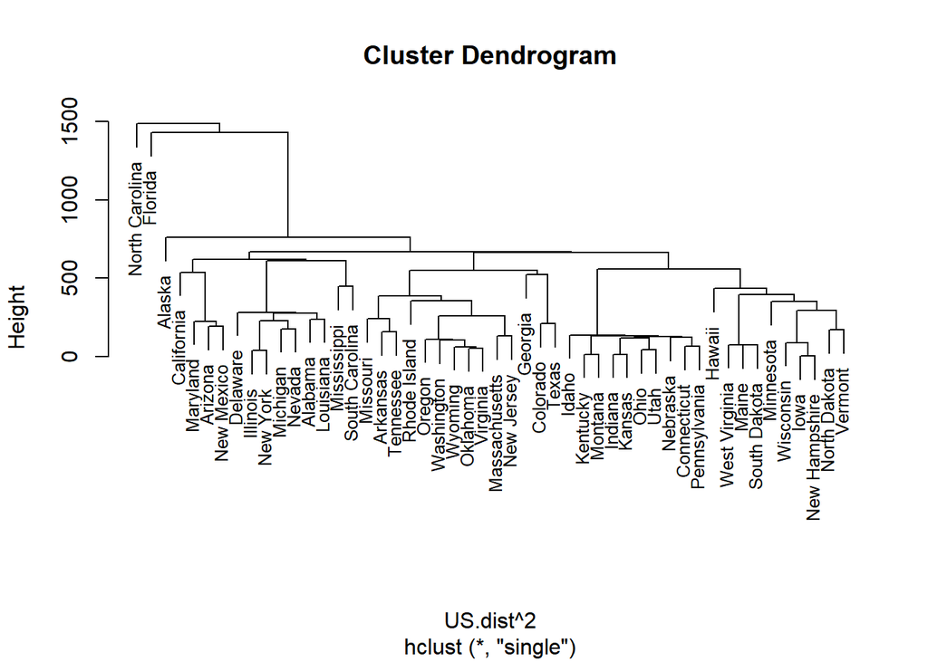

```r
US <- USArrests
US.dist <- dist(US, "euclidean")

US.single <- hclust(US.dist^2, "single")
US.complete <- hclust(US.dist^2, "complete")
US.average <- hclust(US.dist^2, "average")

plot(US.single, cex = 0.8)
```

###### 원하는 수의 그룹으로 분할

cutree(hclust, h, k) - h : 덴드로그램 높이 - k : 그룹의 수

```r
group <- cutree(US.single, k = 6)
group
```

```
##        Alabama         Alaska        Arizona       Arkansas     California
##              1              2              1              3              1
##       Colorado    Connecticut       Delaware        Florida        Georgia
##              3              4              1              5              3
##         Hawaii          Idaho       Illinois        Indiana           Iowa
##              4              4              1              4              4
##         Kansas       Kentucky      Louisiana          Maine       Maryland
##              4              4              1              4              1
##  Massachusetts       Michigan      Minnesota    Mississippi       Missouri
##              3              1              4              1              3
##        Montana       Nebraska         Nevada  New Hampshire     New Jersey
##              4              4              1              4              3
##     New Mexico       New York North Carolina   North Dakota           Ohio
##              1              1              6              4              4
##       Oklahoma         Oregon   Pennsylvania   Rhode Island South Carolina
##              3              3              4              3              1
##   South Dakota      Tennessee          Texas           Utah        Vermont
##              4              3              3              4              4
##       Virginia     Washington  West Virginia      Wisconsin        Wyoming
##              3              3              4              4              3
```

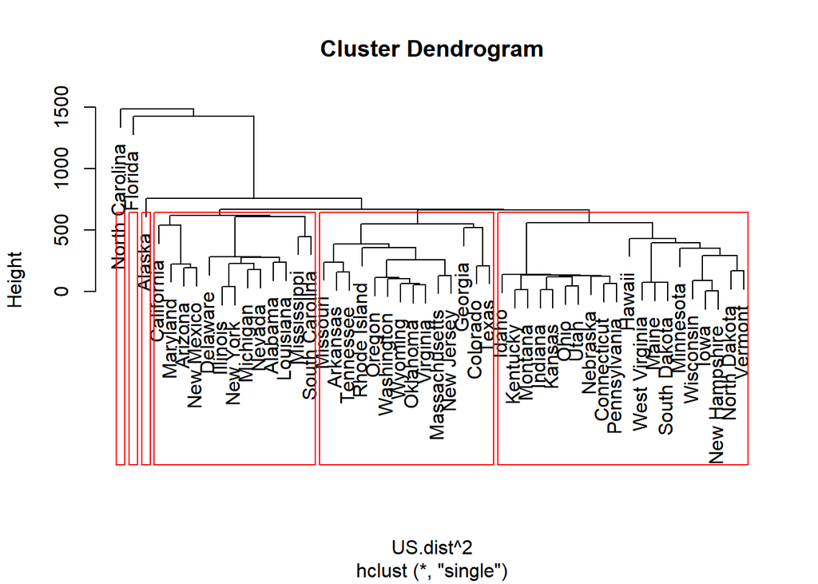

```r
plot(US.single)
rect.hclust(US.single, k = 6, border = "red")
```

#### 비계층적 군집분석

###### K-평균 군집분석

- 원하는 군집 개수, 초기 값 설정 => 초기값 중심으로 군집 형성 => 각 데이터를 거리가 가장 가까운 초기값이 있는 군집으로 분류 => 각 군집의 초기값을 다시 계산 => 변하지 않을 때 까지 반복
- 탐욕적 알고리즘 (초기 중심으로부터의 오차 제곱합을 최소화하는 방향으로 군집 형성)
- 잡음이나 이상값의 영향을 많이 받음, 결과 해석 어려움, 초기 군집 수 결정 어려움

kmeans(data, k, …) - k : 군집의 개수

```r
credit <- read.csv("C:/Users/이찬솔/Desktop/숭실/R/ADP/실기/PART 05 실습용 데이터/credit_final.csv", header = T, sep = ",")
idx <- sample(1:nrow(credit), nrow(credit)*0.7, replace = FALSE)
train <- credit[idx,] ; test <- credit[-idx,]

credit.kmeans <- kmeans(train, 2)
names(credit.kmeans)
```

```
## [1] "cluster"      "centers"      "totss"        "withinss"     "tot.withinss"
## [6] "betweenss"    "size"         "iter"         "ifault"
```

- totss : 전체 변동
- betweenss : 군집 간 변동

```r
(kmeans.table <- table(credit.kmeans$cluster, train$credit.rating))
```

```
##
##       0   1
##   1 156 423
##   2  51  70
```

```r
mean(credit.kmeans$cluster-1 == train$credit.rating)
```

```
## [1] 0.3228571
```

```r
credit.kmeans$betweenss / credit.kmeans$totss
```

```
## [1] 0.7013342
```

###### 최적의 k탐색

NbClust(data, mmin.nc, max.nc, method) - min.nc : 최소 군집의 수 - max.nc : 최대 군집의 수 - method : 군집분석의 방법 (“kmeans”, “median”, “single”, “complete”, “average”)

```r
library(NbClust)
```

```
## [1] "Frey index : No clustering structure in this data set"
```

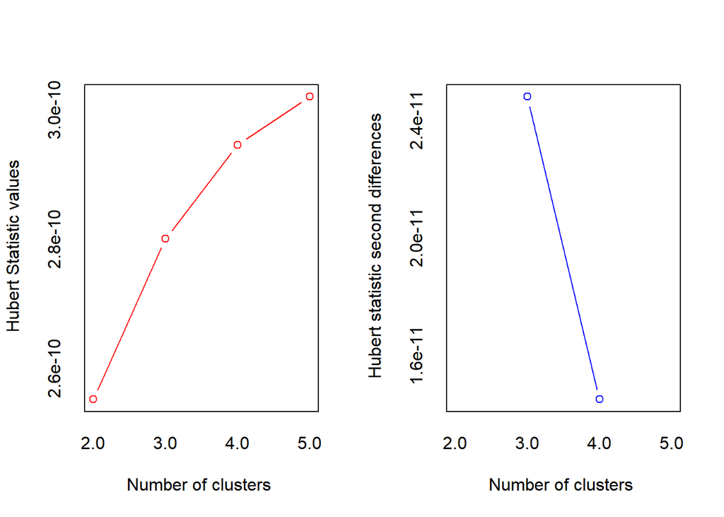

```
## *** : The Hubert index is a graphical method of determining the number of clusters.
##                 In the plot of Hubert index, we seek a significant knee that corresponds to a
##                 significant increase of the value of the measure i.e the significant peak in Hubert
##                 index second differences plot.
##
```

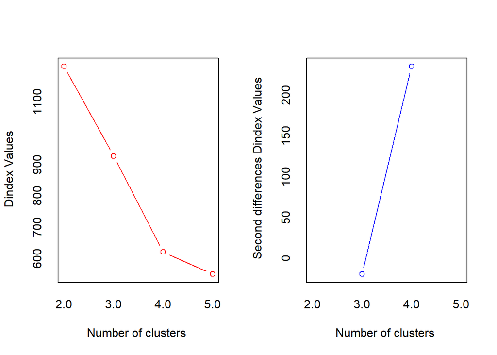

```
## *** : The D index is a graphical method of determining the number of clusters.
##                 In the plot of D index, we seek a significant knee (the significant peak in Dindex
##                 second differences plot) that corresponds to a significant increase of the value of
##                 the measure.
##
## * Among all indices:
## * 7 proposed 2 as the best number of clusters
## * 5 proposed 3 as the best number of clusters
## * 8 proposed 4 as the best number of clusters
## * 3 proposed 5 as the best number of clusters
##
##                    ***** Conclusion *****
##
## * According to the majority rule, the best number of clusters is  4
##
##
```

```r
nc <- NbClust(train, min.nc = 2, max.nc = 5, method = "kmeans")
```

#### 혼합 분포 군집

- 모형 기반의 군집
- 데이터가 k개의 모수적 모형의 가중합으로 표현되는 모집단 모형으로부터 나왔다는 가정하에서 모수와 함꼐 가중치를 자료로부터 추정하는 방법을 사용
- K개의 각 모형은 군집을 의미하며. 각 데이터는 추정된 K개의 모형 중 어느 모형으로 나왔을 확률이 높은지에 따라 군집의 분류가 이루어짐
- 모수와 가중치의 최대가능도추정에는 EM알고리즘 사용

##### EM 알고리즘

- E-단계 : 잠재변수 Z의 기대치 계산
- M-단계 : 잠재변수 Z의 기대치를 이용하여 파라미터 추정
- K-평균군집과 유사, but 확률분포를 도입하여 군집을 수행
- 이상치에 민감
- 군집을 몇 개의 모수로 표현 가능

Mclust(data, G, …) - G : BIC를 계산할 혼합분포 클러스터의 수를 지정

```r
library(mclust)
```

```r
mc <- Mclust(iris[,1:4], G = 3)
```

```r
summary(mc, parameters = TRUE)
```

```
## ----------------------------------------------------
## Gaussian finite mixture model fitted by EM algorithm
## ----------------------------------------------------
##
## Mclust VEV (ellipsoidal, equal shape) model with 3 components:
##
##  log-likelihood   n df       BIC       ICL
##        -186.074 150 38 -562.5522 -566.4673
##
## Clustering table:
##  1  2  3
## 50 45 55
##
## Mixing probabilities:
##         1         2         3
## 0.3333333 0.3005423 0.3661243
##
## Means:
##               [,1]     [,2]     [,3]
## Sepal.Length 5.006 5.915044 6.546807
## Sepal.Width  3.428 2.777451 2.949613
## Petal.Length 1.462 4.204002 5.482252
## Petal.Width  0.246 1.298935 1.985523
##
## Variances:
## [,,1]
##              Sepal.Length Sepal.Width Petal.Length Petal.Width
## Sepal.Length   0.13320850  0.10938369  0.019191764 0.011585649
## Sepal.Width    0.10938369  0.15495369  0.012096999 0.010010130
## Petal.Length   0.01919176  0.01209700  0.028275400 0.005818274
## Petal.Width    0.01158565  0.01001013  0.005818274 0.010695632
## [,,2]
##              Sepal.Length Sepal.Width Petal.Length Petal.Width
## Sepal.Length   0.22572159  0.07613348   0.14689934  0.04335826
## Sepal.Width    0.07613348  0.08024338   0.07372331  0.03435893
## Petal.Length   0.14689934  0.07372331   0.16613979  0.04953078
## Petal.Width    0.04335826  0.03435893   0.04953078  0.03338619
## [,,3]
##              Sepal.Length Sepal.Width Petal.Length Petal.Width
## Sepal.Length   0.42943106  0.10784274   0.33452389  0.06538369
## Sepal.Width    0.10784274  0.11596343   0.08905176  0.06134034
## Petal.Length   0.33452389  0.08905176   0.36422115  0.08706895
## Petal.Width    0.06538369  0.06134034   0.08706895  0.08663823
```

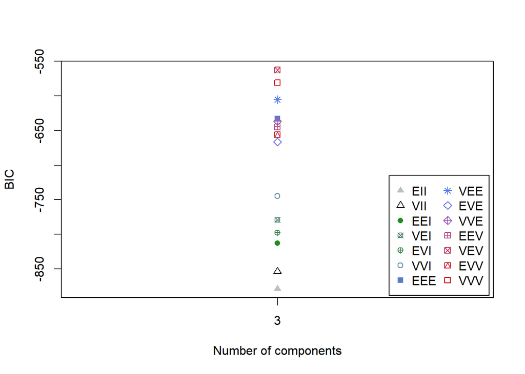

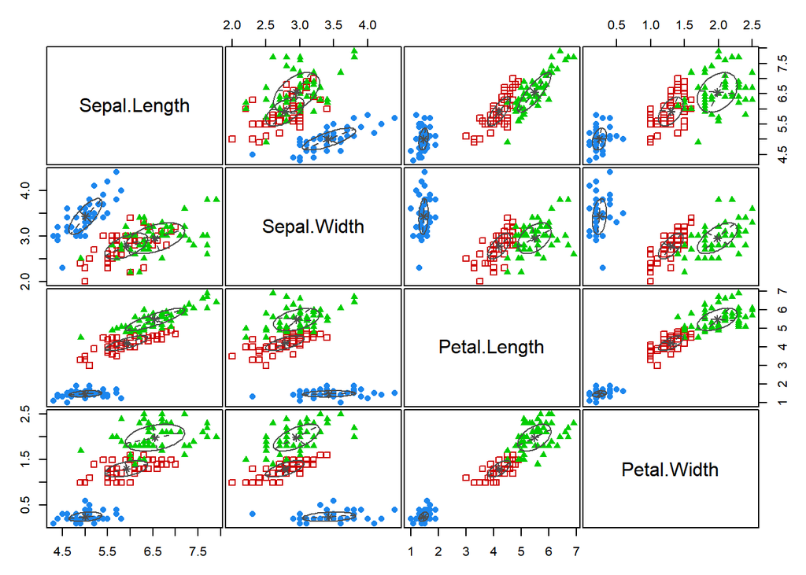

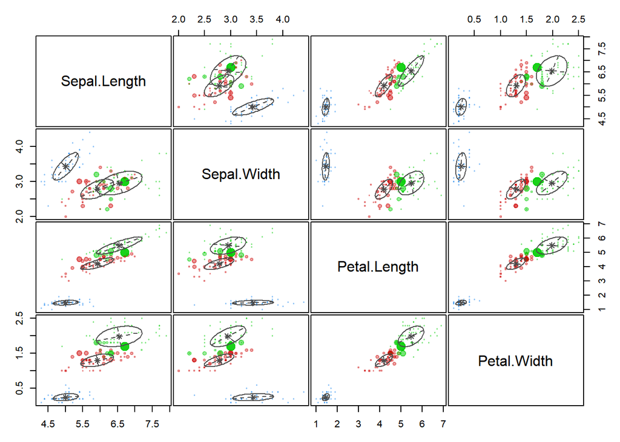

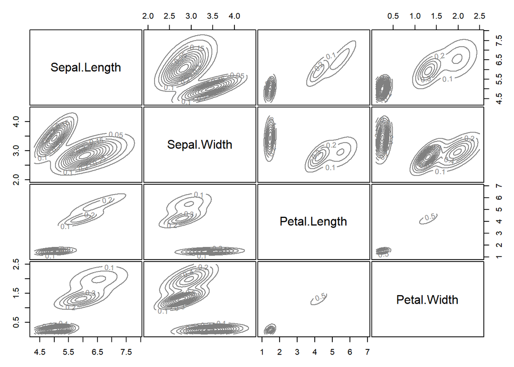

```r
plot.Mclust(mc)
```

- 군집 분류 결과

```r
mc$classification
```

```
##   [1] 1 1 1 1 1 1 1 1 1 1 1 1 1 1 1 1 1 1 1 1 1 1 1 1 1 1 1 1 1 1 1 1 1 1 1 1 1
##  [38] 1 1 1 1 1 1 1 1 1 1 1 1 1 2 2 2 2 2 2 2 2 2 2 2 2 2 2 2 2 2 2 3 2 3 2 3 2
##  [75] 2 2 2 3 2 2 2 2 2 3 2 2 2 2 2 2 2 2 2 2 2 2 2 2 2 2 3 3 3 3 3 3 3 3 3 3 3
## [112] 3 3 3 3 3 3 3 3 3 3 3 3 3 3 3 3 3 3 3 3 3 3 3 3 3 3 3 3 3 3 3 3 3 3 3 3 3
## [149] 3 3
```

#### 연관분석

- 지지도 : A와 B 동시 포함할 확률
- 신뢰도 : A를 포함한 거래 중 A와 B를 같이 포함할 확률
- 향상도 : A가 구매되지 않았을 때, 품목 B의 구매확률에 비해 A가 구매됐을 때 품목 B의 구매확률의 증가비 (A와 B가 관련이 없다면 향상도 = 1)

##### Apriori

- 빈발항목집합 : 최소 지지도보다 큰 지지도 값을 갖는 품목의 집합
- Apriori는 최소 지지도 이상의 빈발항목집합을 찾은 후 그것들에 대해서만 연관규칙 계산

###### 데이터를 트랜잭션 형태로 변경

as(data, class, …) - class : data를 변경할 클래스 이름 (연관분석 : “transactions”)

###### 연관분석 결과

inspect(x, …)

```r
library(arules)
```

```r
id <- c(1, 2, 3, 4, 5, 6)
gender <- c("FEMALE", "MALE", "FEMALE", "FEMALE", "MALE", "FEMALE")
age <- c("age_20", "age_20", "age_40", "age_30", "age_40", "age_30")
rank <- c("Gold", "Silver", "Silver", "VIP", "Gold", "Gold")
mobile_app_use <- c("YES", "YES", "NO", "YES", "NO", "YES")
re_order <- c("YES", "NO", "NO", "YES", "NO", "YES")

cust_tel <- cbind(id, gender, age, rank, mobile_app_use, re_order)
cust_tel <- as.data.frame(cust_tel)

cust_tel_1 <- subset(cust_tel, select = -c(id))
```

```r
(tran.cust <- as(cust_tel_1, "transactions"))
```

```
## transactions in sparse format with
##  6 transactions (rows) and
##  12 items (columns)
```

```r
inspect(tran.cust)
```

```
##     items                 transactionID
## [1] {gender=FEMALE,
##      age=age_20,
##      rank=Gold,
##      mobile_app_use=YES,
##      re_order=YES}                    1
## [2] {gender=MALE,
##      age=age_20,
##      rank=Silver,
##      mobile_app_use=YES,
##      re_order=NO}                     2
## [3] {gender=FEMALE,
##      age=age_40,
##      rank=Silver,
##      mobile_app_use=NO,
##      re_order=NO}                     3
## [4] {gender=FEMALE,
##      age=age_30,
##      rank=VIP,
##      mobile_app_use=YES,
##      re_order=YES}                    4
## [5] {gender=MALE,
##      age=age_40,
##      rank=Gold,
##      mobile_app_use=NO,
##      re_order=NO}                     5
## [6] {gender=FEMALE,
##      age=age_30,
##      rank=Gold,
##      mobile_app_use=YES,
##      re_order=YES}                    6
```

apriori(data, parameter, appearance, control) - parameter : 최소 지지도(supp), 신뢰도(conf), 최대 아이템 개수(maxlen), 최소 아이템 개수(minlen) - appearance : 특정 연관규칙 결과 탐색 - control : 결과 보여주기 등의 알고리즘 성능 조정

```r
data("Groceries")
Groceries
```

```
## transactions in sparse format with
##  9835 transactions (rows) and
##  169 items (columns)
```

```r
inspect(Groceries[1:3])
```

```
##     items
## [1] {citrus fruit,
##      semi-finished bread,
##      margarine,
##      ready soups}
## [2] {tropical fruit,
##      yogurt,
##      coffee}
## [3] {whole milk}
```

```r
rules <- apriori(Groceries, parameter = list(support = 0.01, confidence = 0.3))
```

```
## Apriori
##
## Parameter specification:
##  confidence minval smax arem  aval originalSupport maxtime support minlen
##         0.3    0.1    1 none FALSE            TRUE       5    0.01      1
##  maxlen target  ext
##      10  rules TRUE
##
## Algorithmic control:
##  filter tree heap memopt load sort verbose
##     0.1 TRUE TRUE  FALSE TRUE    2    TRUE
##
## Absolute minimum support count: 98
##
## set item appearances ...[0 item(s)] done [0.00s].
## set transactions ...[169 item(s), 9835 transaction(s)] done [0.01s].
## sorting and recoding items ... [88 item(s)] done [0.00s].
## creating transaction tree ... done [0.01s].
## checking subsets of size 1 2 3 4 done [0.00s].
## writing ... [125 rule(s)] done [0.00s].
## creating S4 object  ... done [0.00s].
```

- 최소 지지도 : 0.01, 최소 신뢰도 0.3
- 분석 결과 : 125개의 연관규칙

```r
inspect(sort(rules, by = c("confidence"), decreasing = T)[1:5])
```

```
##     lhs                                  rhs                support
## [1] {citrus fruit, root vegetables}   => {other vegetables} 0.01037112
## [2] {tropical fruit, root vegetables} => {other vegetables} 0.01230300
## [3] {curd, yogurt}                    => {whole milk}       0.01006609
## [4] {other vegetables, butter}        => {whole milk}       0.01148958
## [5] {tropical fruit, root vegetables} => {whole milk}       0.01199797
##     confidence coverage   lift     count
## [1] 0.5862069  0.01769192 3.029608 102
## [2] 0.5845411  0.02104728 3.020999 121
## [3] 0.5823529  0.01728521 2.279125  99
## [4] 0.5736041  0.02003050 2.244885 113
## [5] 0.5700483  0.02104728 2.230969 118
```

- confidence에 따라 내림차순, 1 ~ 5위 까지의 연관규칙 확인
- lhs는 좌항, rhs는 우항, 좌항을 구매했을 때 우항을 구매하는 규칙
- confidence가 높다는 뜻은 구매 품목들의 연관성이 높음을 의미
- lift가 높다는 뜻은 좌항의 제품을 구매할 때, 우항의 제품을 구매할 확률이 약 n배 가량 높음
- 좌항에서 우항, 우항에서 좌항의 규칙이 겹치는 경우가 있으므로, 중복규칙은 제거해야함
- 중복 가지치기 함수 생성

```r
prune.dup.rules <- function(rules){
  rule.subset.matrix <- is.subset(rules, rules, sparse = F)
  rule.subset.matrix[lower.tri(rule.subset.matrix, diag = T)] <- NA
  dup.rules <- colSums(rule.subset.matrix, na.rm = T) >= 1
  pruned.rules <- rules[!dup.rules]
  return(pruned.rules)
}
```

###### 우변의 아이템 구매를 이끌 아이템 세트 찾기

```r
metric.params <- list(supp = 0.001, conf = 0.5, minlen = 2) # minlen은 좌항과 우항을 합친 최소 물품수
rules <- apriori(data = Groceries, parameter = metric.params,
                appearance = list(default = "lhs", rhs = "soda"), # 우측의 soda를 사기위해 좌항의 아이템을 찾는 것.
                control = list(verbose = F)) # verbose는 apriori함수 실행 결과를 나타내지 않음을 지시.

rules <- prune.dup.rules(rules) # 중복 규칙 가지치기 실시
rules <- sort(rules, decreasing = TRUE, by = "confidence") # confidence를 기준으로 정렬

inspect(rules[1:5])
```

```
##     lhs                                       rhs    support     confidence
## [1] {coffee, misc. beverages}              => {soda} 0.001016777 0.7692308
## [2] {sausage, bottled water, bottled beer} => {soda} 0.001118454 0.7333333
## [3] {sausage, white bread, shopping bags}  => {soda} 0.001016777 0.6666667
## [4] {rolls/buns, bottled water, chocolate} => {soda} 0.001321810 0.6500000
## [5] {pastry, misc. beverages}              => {soda} 0.001220132 0.6315789
##     coverage    lift     count
## [1] 0.001321810 4.411303 10
## [2] 0.001525165 4.205442 11
## [3] 0.001525165 3.823129 10
## [4] 0.002033554 3.727551 13
## [5] 0.001931876 3.621912 12
```

- coffee와 misc.beverages를 함꼐 구매할 경우 soda를 구매한다는 규칙의 confidence가 가장 높음

###### 좌변의 아이템 세트를 가지고 있을 때 물품 찾기

```r
metric.params <- list(supp = 0.001, conf = 0.3, minlen = 2)
rules <- apriori(data = Groceries, parameter=metric.params,
               appearance = list(default = "rhs", # yogurt, sugar를 구매했을 때, 우항의 아이템을 찾는 것.
                                 lhs = c("yogurt", "sugar")),
               control = list(verbose=F))
rules <- prune.dup.rules(rules)
rules <- sort(rules, decreasing = TRUE, by = "confidence")
inspect(rules[1:5])
```

```
##     lhs                rhs                  support     confidence coverage
## [1] {sugar}         => {whole milk}         0.015048297 0.4444444  0.033858668
## [2] {yogurt}        => {whole milk}         0.056024403 0.4016035  0.139501779
## [3] {sugar}         => {other vegetables}   0.010777834 0.3183183  0.033858668
## [4] {yogurt}        => {other vegetables}   0.043416370 0.3112245  0.139501779
## [5] {yogurt, sugar} => {whipped/sour cream} 0.002135231 0.3088235  0.006914082
##     lift     count
## [1] 1.739400 148
## [2] 1.571735 551
## [3] 1.645119 106
## [4] 1.608457 427
## [5] 4.308198  21
```

- sugar를 구매하면 whole milk를 구매한다는 규칙의 confidence가 가장 높게 나타남을 확인